```python
from sklearn.cluster import KMeans
import numpy as np
from src.data_management.RecSys2019Reader import RecSys2019Reader
from src.data_management.RecSys2019Reader_utils import get_ICM_numerical
from src.data_management.data_reader import read_target_users, read_URM_cold_all
import pandas as pd
import scipy.sparse as sps
import matplotlib.pyplot as plt
```

```python
df_UCM_age = pd.read_csv("../data/data_UCM_age.csv")
df_UCM_region = pd.read_csv("../data/data_UCM_region.csv")
df_URM = pd.read_csv("../data/data_train.csv")

user_list = df_URM['row']
item_list = df_URM['col']
user_list_unique = list(set(user_list))
item_list_unique = list(set(item_list))
URM_all = sps.coo_matrix((np.ones(len(df_URM)), (user_list, item_list)))
URM_all = URM_all.tocsr()
URM_all
```

```
<30911x18495 sparse matrix of type '<class 'numpy.float64'>'
	with 398636 stored elements in Compressed Sparse Row format>
```

# Outliers detection?

```python
df_UCM_age['row'].unique().shape
```

```
(30317,)
```

```python
df_UCM_age.shape
```

```
(30317, 3)
```

For each user we have a different age, and this is fine

```python
df_UCM_region['row'].unique().shape
```

```
(26375,)
```

```python
df_UCM_region.shape
```

```
(26609, 3)
```

```python
region_arr = df_UCM_region['row'].values
```

```python
region_arr
```

```
array([    0,     0,     1, ..., 30907, 30909, 30910], dtype=int64)
```

```python
u, c = np.unique(region_arr, return_counts=True)
dup = u[c > 1]
```

```python
dup.shape
```

```
(234,)
```

```python
np.unique(dup).shape
```

```
(234,)
```

```python
df_UCM_region.shape[0] - dup.shape[0]
```

```
26375
```

Therefore, all users that are duplicates, have all ONLY two regions.

# Missing values?

```python
URM_users = df_URM.row.unique()
UCM_age_users = df_UCM_age.row.unique()
mask = np.in1d(URM_users, UCM_age_users, assume_unique=True) # users of the URM for which we do not have data in the UCM
```

### Age - Are they cold?

```python
# Let's see if these missing users in the UCM, are cold users or not.
user_act = (URM_all > 0).sum(axis=1)
user_act = np.array(user_act).squeeze()
user_act = np.sort(user_act)
condition = user_act == 0
cold_user = np.extract(condition, user_act)
user_act = (URM_all > 0).sum(axis=1)
user_act = np.array(user_act).squeeze()
cold_users = np.argsort(user_act)[0:cold_user.shape[0]] # COLD USERS ID
```

```python
# Let's see if for the cold users we have information regarding the age
new_mask = np.in1d(UCM_age_users, cold_users)
```

```python
UCM_age_users[new_mask].shape
```

```
(3579,)
```

```python
cold_users.shape
```

```
(3656,)
```

There are 3656 users that are cold. For 3579 of them, we have age information.

### Region - Are they cold?

```python
UCM_region_users = df_UCM_region['row'].unique()
```

```python
new_mask = np.in1d(UCM_region_users, cold_users)
UCM_region_users[new_mask].shape
```

```
(3104,)
```

```python
cold_users.shape
```

```
(3656,)
```

For the region instead, there are 500 cold users for which we do not have information in the UCM.

### What about the missing values in the two tables?

As already seen in other notebooks, we have the following results.

```python
URM_users = df_URM.row.unique()
print("There are %d users in URM"%len(URM_users), end="")
UCM_age_users = df_UCM_age.row.unique()
print(", while there are %d users in UCM_age."%len(UCM_age_users))
mask = np.in1d(URM_users, UCM_age_users, assume_unique=True)
print("But there are %d users in URM and not in UCM_age"%len(URM_users[~mask]))
```

```
There are 27255 users in URM, while there are 30317 users in UCM_age.
But there are 517 users in URM and not in UCM_age
```

```python
URM_users = df_URM.row.unique()
print("There are %d users in URM"%len(URM_users), end="")
UCM_region_users = df_UCM_region.row.unique()
print(", while there are %d users in UCM_age."%len(UCM_age_users))
mask = np.in1d(URM_users, UCM_region_users, assume_unique=True)
print("But there are %d users in URM and not in UCM_region"%len(URM_users[~mask]))
```

```
There are 27255 users in URM, while there are 30317 users in UCM_age.
But there are 3984 users in URM and not in UCM_region
```

# Mix UCM

```python
UCM_age = df_UCM_age[['row', 'col']]
```

```python
UCM_age.rename(columns={'row':'user',
                          'col':'age'},
                 inplace=True)
```

```python
UCM_region = df_UCM_region[['row', 'col']]
UCM_region.rename(columns={'row':'user', 'col':'region'}, inplace=True)
```

```python
UCM_age_region = pd.merge(UCM_region, UCM_age, on="user", how="outer")
```

```python
UCM_age_region.loc[UCM_age_region['age'].isnull(), 'age'] = int(UCM_age_region['age'].mean()) + 1
```

```python
UCM_age_region.loc[UCM_age_region['region'].isnull(), 'region'] = -1
```

Let's try to add the user profile len to this dataframe

```python
user_act = URM_all.sum(axis=1)
user_act = np.array(user_act).squeeze()
```

```python
df_user_act = pd.DataFrame(user_act)
```

```python
df_user_act.rename(columns={0:'activity'},
                 inplace=True)
```

```python
merged = pd.merge(UCM_age_region, df_user_act, right_index=True, left_on="user")
```

# Data preprocessing

One-hot encode the dataframe columns of region + age normalizing + user profile len normalizing

```python
dfDummies = pd.get_dummies(merged[['user','region']]['region'], prefix='region')
```

```python
dfDummies = dfDummies.join(merged['user'])
```

```python
dfDummies = dfDummies.groupby(['user'], as_index=False).sum()
```

```python
merged = merged[['user', 'age', 'activity']]
```

```python
merged = pd.merge(merged, dfDummies, on="user")
```

```python
merged = merged.drop_duplicates(subset ="user",
                     keep = 'first', inplace = False)
```

```python
from sklearn.preprocessing import Normalizer
```

```python
transformer = Normalizer()
```

```python
temp = merged['age'].values.tolist()
temp = [temp]
```

```python
transformer.fit(temp)
```

```
Normalizer(copy=True, norm='l2')
```

```python
res = transformer.transform(temp)
```

```python
age_norm = pd.DataFrame(res[0])
age_norm.rename(columns={0:'age_norm'},
                 inplace=True)
```

```python
merged = pd.merge(merged, age_norm, right_index=True, left_on="user")
```

```python
merged = merged[['user', 'activity', 'region_-1.0', 'region_0.0', 'region_2.0',
       'region_3.0', 'region_4.0', 'region_5.0', 'region_6.0', 'region_7.0',
       'age_norm']]
```

```python
act = merged['activity'].values
```

User activity is highly skewed, as we know, so, we may want to have some gaussian distribution in [0, 1]

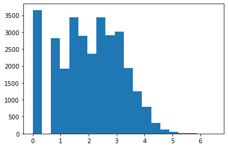

```python
new_act = np.log1p(act)
plt.hist(new_act, bins=20)
plt.show()
```

```python
transformer = Normalizer()
new_act = [new_act]
transformer.fit(new_act)
```

```
Normalizer(copy=True, norm='l2')
```

```python
res = transformer.transform(new_act)
```

```python
act_norm = pd.DataFrame(res[0])
act_norm.rename(columns={0:'act_norm'},
                 inplace=True)
```

```python
merged = pd.merge(merged, act_norm, right_index=True, left_on="user")
```

```python
merged.drop(columns=['activity'], inplace=True)
```

```python
merged.head()
```

|  | user | region_-1.0 | region_0.0 | region_2.0 | region_3.0 | region_4.0 | region_5.0 | region_6.0 | region_7.0 | age_norm | act_norm |
| --- | --- | --- | --- | --- | --- | --- | --- | --- | --- | --- | --- |
| 0 | 0 | 0 | 1 | 0 | 0 | 0 | 0 | 1 | 0 | 0.005611 | 0.005087 |
| 2 | 1 | 0 | 1 | 0 | 0 | 0 | 0 | 0 | 1 | 0.005611 | 0.004761 |
| 4 | 2 | 0 | 0 | 0 | 0 | 0 | 1 | 0 | 0 | 0.004489 | 0.005867 |
| 5 | 3 | 0 | 1 | 0 | 0 | 0 | 0 | 0 | 0 | 0.005611 | 0.001696 |
| 6 | 4 | 0 | 1 | 0 | 0 | 0 | 1 | 0 | 0 | 0.005611 | 0.005376 |

```python
merged.shape
```

```
(30911, 11)
```

```python
merged = merged.set_index('user')
```

```python
merged = merged.sort_index()
```

```python
merged.head()
```

| user | region_-1.0 | region_0.0 | region_2.0 | region_3.0 | region_4.0 | region_5.0 | region_6.0 | region_7.0 | age_norm | act_norm |
| --- | --- | --- | --- | --- | --- | --- | --- | --- | --- | --- |
| 0 | 0 | 1 | 0 | 0 | 0 | 0 | 1 | 0 | 0.005611 | 0.005087 |
| 1 | 0 | 1 | 0 | 0 | 0 | 0 | 0 | 1 | 0.005611 | 0.004761 |
| 2 | 0 | 0 | 0 | 0 | 0 | 1 | 0 | 0 | 0.004489 | 0.005867 |
| 3 | 0 | 1 | 0 | 0 | 0 | 0 | 0 | 0 | 0.005611 | 0.001696 |
| 4 | 0 | 1 | 0 | 0 | 0 | 1 | 0 | 0 | 0.005611 | 0.005376 |

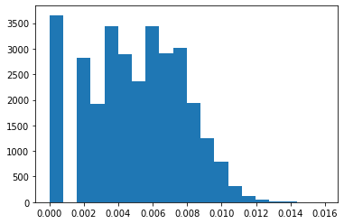

```python
plt.hist(merged['act_norm'].values, bins=20)
plt.show()
```

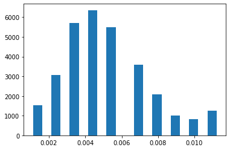

```python
plt.hist(merged['age_norm'].values, bins=20)
plt.show()
```